# Interval estimation of a population mean

Gleb Zakhodyakin, postlogist@gmail.com

19.01.2018

## Why care about confidence intervals?

A common research problem is making conclusions about a large **population** based on limited data. Such data are collected by randomly selecting a small **sample** from the population. Since sampling process involves randomness, there will be an error in estimates based on sample data - the **sampling error**. This simply means that if someone decides to explore the same population and studies another sample of the same size, he/she will get different results.

Statistics provides several ways for estimating the uncertainty associated with estimates of population parameters based on sample data. First, there is a concept of a **standard error**. This statistic is computed from sample data and allows to estimate the variation of possible results based on samples of the same size. The standard error can be computed for any sample statistic.

Next, there is a concept of a **confidence interval**. The confidence interval is constructed around the estimate based on a sample. The interval’s width allows to assess how close that estimate might be to the true value of a population parameter. A **confidence level** is associated with a confidence interval. This is a probability of getting the true value of a population parameter within the interval when doing a repeated estimation of that parameter based on samples of the same size.

In this example, we will illustrate the algorithm for constructing the **confidence interval for a population mean**.

## Generating population data

We will study a (fake) population of people with objective to estimate the average height. We will estimate the average height based on a small sample of just 9 people randomly selected from the entire population. To save us effort, we will generate the data on population height instead of going into the field and trying to measure it ourselves. The population data will be sampled using R’s facilities. All in all, we are just trying to understand the statistical inference machinery…

First, we need to load packages and to generate population data. Our population includes 10000 people. The height in population is normally distributed with mean 175 cm and standard deviation 10 cm.

```r
library(tidyverse)
```

```r
set.seed(435) # to initialize the random number generator, for reproducibility
height <- round(rnorm(10000, 175, 10))
```

**Notes:**

- Notice the `set.seed()` function. It initializes the random number generator with a specific number. All the “random” numbers in a computer are actually only looking random, but in practice they are generated by a deterministic algorithm. Including the `set.seed()` in your script ensures reproducibility - we’ll get the same results each time despite using “randomness”.
- R has quite a few functions to work with probability distributions. See `?Distributions` to get a list of supported distributions.

The resulting distribution of heights in the population:

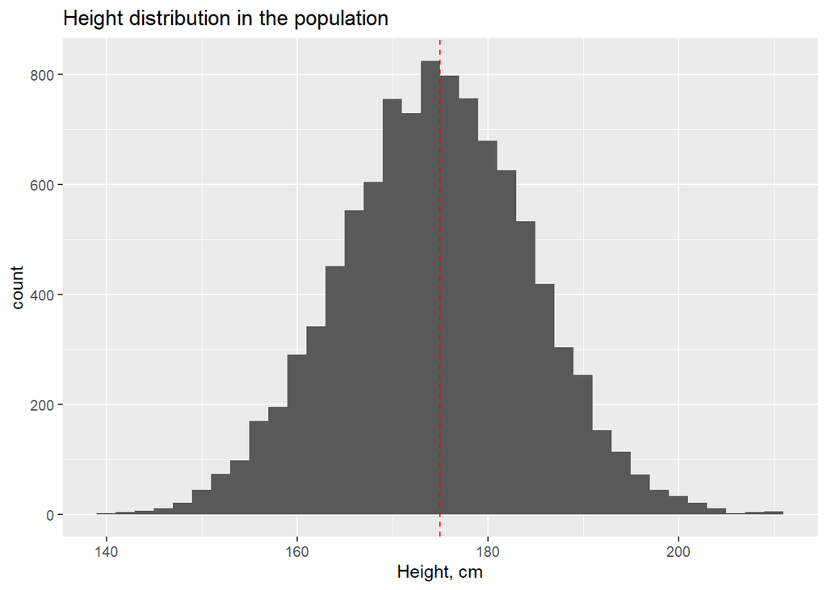

```r
ggplot(data = tibble(height), aes(x = height)) +
  geom_histogram(binwidth = 2) +
  geom_vline(aes(xintercept = mean(height)),
             colour='red',
             linetype='dashed')+
  ggtitle('Height distribution in the population') +
  xlab('Height, cm')
```

## Sampling

Next, we draw a random sample from the population:

```r
# Sampling
set.seed(435)
N <- 9
height_sample <- sample(height, size = N)
```

**Note:** the `sample()` function will randomly select a given number of elements from a *vector*. It can’t work with data frames, so if you need to sample a data frame, use `dplyr::sample_n()` or `dplyr::sample_frac()` functions.

```r
# A vector with row indices is sampled
my_df <- tibble(x = 1:10, y = 101:110)
my_df
```

```
## # A tibble: 10 x 2
##        x     y
##    <int> <int>
##  1     1   101
##  2     2   102
##  3     3   103
##  4     4   104
##  5     5   105
##  6     6   106
##  7     7   107
##  8     8   108
##  9     9   109
## 10    10   110
```

```r
set.seed(435)
# A given number of rows
my_df %>% sample_n(size = 5)
```

```
## # A tibble: 5 x 2
##       x     y
##   <int> <int>
## 1     6   106
## 2    10   110
## 3     2   102
## 4     1   101
## 5     5   105
```

```r
set.seed(435)
# A given proportion of rows
my_df %>% sample_frac(size = 0.5)
```

```
## # A tibble: 5 x 2
##       x     y
##   <int> <int>
## 1     6   106
## 2    10   110
## 3     2   102
## 4     1   101
## 5     5   105
```

In some cases you may need to use a trick described as follows.

You can sample a data frame in two steps:

1. First, create a sequence of row indices of the same length as the data frame.
2. Sample the sequence and use the resulting indices to extract the actual rows of the data frame:

```r
set.seed(435)
selected <- 1:nrow(my_df) %>% sample(size = 5)

# These indices are used for extracting the selected rows:
my_df[selected, ] #rows in the sample
```

```
## # A tibble: 5 x 2
##       x     y
##   <int> <int>
## 1     6   106
## 2    10   110
## 3     2   102
## 4     1   101
## 5     5   105
```

```r
my_df[-selected, ] #rows not in the sample
```

```
## # A tibble: 5 x 2
##       x     y
##   <int> <int>
## 1     3   103
## 2     4   104
## 3     7   107
## 4     8   108
## 5     9   109
```

## Interval estimation of the population mean

The first step is making *point estimates* of population parameters based on our sample.

```r
# The sample
height_sample
```

```
## [1] 172 165 181 178 184 177 167 180 182
```

```r
# Sample mean
sample_mean <- mean(height_sample)
paste("Sample mean:", sample_mean)
```

```
## [1] "Sample mean: 176.222222222222"
```

```r
# Sample standard deviation
sample_sd <- sd(height_sample)
paste("Sample S.D.:", sample_sd)
```

```
## [1] "Sample S.D.: 6.74124947205223"
```

Next, we will compute the standard error for the sample mean

```r
# Standard error for the sample mean
sample_se <- sample_sd/sqrt(N)
paste("Std. error for the sample mean:", sample_se)
```

```
## [1] "Std. error for the sample mean: 2.24708315735074"
```

The next step is selecting the **confidence level** $P$ (usually .95) and computing the confidence interval half-width. Since we don’t know the population standard deviation, we’ll use the sample standard deviation for calculating the standard error. This will require using the Student’s t-distribution instead of standard normal distribution to account for increased uncertainty.

```r
P <- .95 # confidence level
alpha <- 1 - P

# quantile
quant <- qt(1 - alpha / 2 , N - 1)

# 95% confidence interval half width
delta <- quant * sample_se
paste("Confidence interval half-width:", round(delta, 1))
```

```
## [1] "Confidence interval half-width: 5.2"
```

Last step is constructing the confidence interval around our estimate of population mean. For this, the half-width is added to/substracted from the sample mean. Upper and lower confidence limits are produced as a result.

```r
#  upper and lower confidence limits:
lcl <- sample_mean - delta
ucl <- sample_mean + delta

c(lcl, ucl)
```

```
## [1] 171.0 181.4
```

## Comparing the estimated value of the population mean to the actual value

Finally, we compute the true population mean and compare our interval estimate to this value. Note that this is only possible since we already know the population.

```r
population_mean <- mean(height)
paste("Population mean:", round(population_mean, 1),
      "Sample mean:", round(sample_mean, 1))
```

```
## [1] "Population mean: 175 Sample mean: 176.2"
```

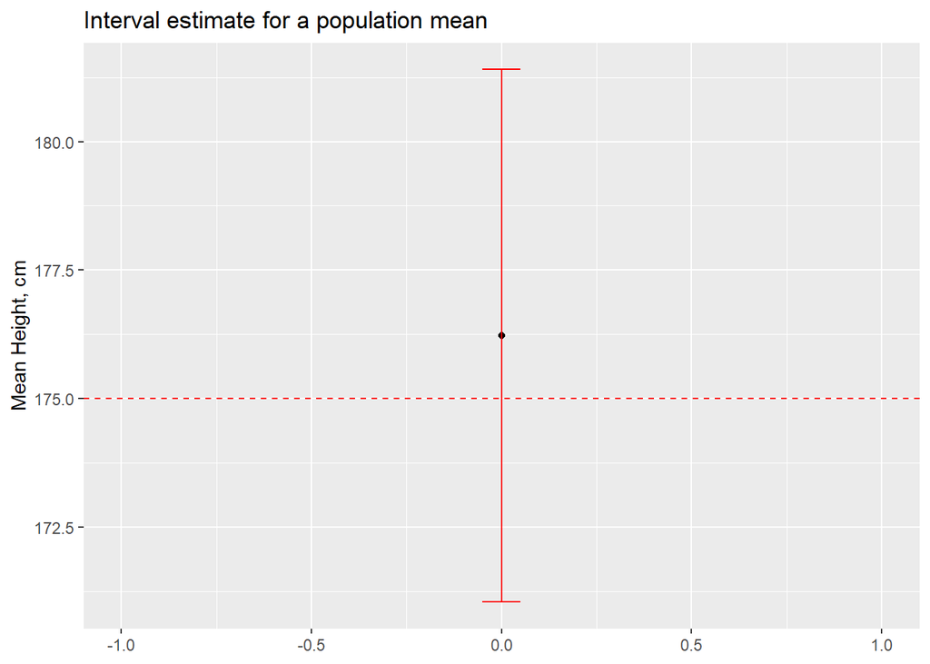

```r
ggplot(data = tibble(population_mean, sample_mean, lcl, ucl),
       aes(x = 0)) +
  geom_point(aes(y = sample_mean)) +
  geom_errorbar(aes(ymin = lcl, ymax = ucl),
                col = 'red', width = 0.1) +
  labs(title = 'Interval estimate for a population mean',
       y = 'Mean Height, cm',
       x = NULL) +
  geom_hline(aes(yintercept = population_mean),
             col = 'red', linetype = 'dashed') +
  xlim(-1, 1)
```

## Computing confidence interval using built-in funcions

There is a much simpler way to compute the confidence interval in R. We can use the built-in `t.test()` function

```r
# A simpler way to get a confidence interval:
t.test(height_sample)
```

```
##
##  One Sample t-test
##
## data:  height_sample
## t = 78, df = 8, p-value = 8e-13
## alternative hypothesis: true mean is not equal to 0
## 95 percent confidence interval:
##  171.0 181.4
## sample estimates:
## mean of x
##     176.2
```

```r
# Extracting the required part of the result:
r <- t.test(height_sample)
names(r)
```

```
##  [1] "statistic"   "parameter"   "p.value"     "conf.int"    "estimate"
##  [6] "null.value"  "stderr"      "alternative" "method"      "data.name"
```

```r
tibble(by_hand = c(lcl, ucl), using_function = as.vector(r$conf.int))
```

```
## # A tibble: 2 x 2
##   by_hand using_function
##     <dbl>          <dbl>
## 1    171.           171.
## 2    181.           181.
```

There’s a handy package called `broom` which aims to make the R’s functions output tidy. Its functions take the results from the statistical/modeling functions and return tidy data frames.

```r
t.test(height_sample) %>% broom::tidy()
```

```
## # A tibble: 1 x 8
##   estimate statistic  p.value parameter conf.low conf.high method
##      <dbl>     <dbl>    <dbl>     <dbl>    <dbl>     <dbl> <chr>
## 1     176.      78.4 7.79e-13         8     171.      181. One S~
## # ... with 1 more variable: alternative <chr>
```

See package vignettes to learn how to use them: `vignette(package = 'broom')` and `vignette(package = 'broom', topic = 'broom')`

There is also a simpler way of plotting the confidence interval using ggplot2. Actually, we don’t need to compute the confience limits and can just use the built-in statistical function for computation.

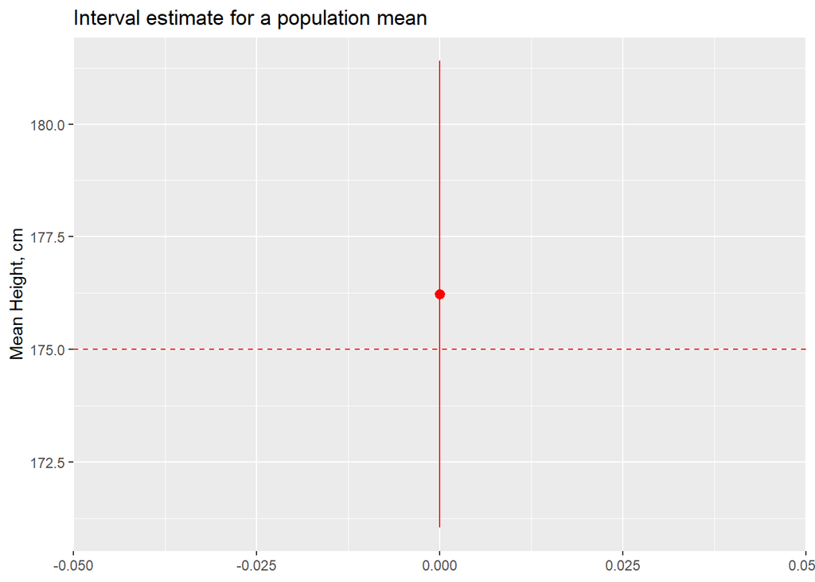

```r
ggplot(data = tibble(height = height_sample)) +
  stat_summary(aes(x = 0, y = height),
               fun.data = 'mean_cl_normal',
               colour = 'red') +
  labs(title = 'Interval estimate for a population mean',
       y = 'Mean Height, cm', x = NULL) +
  geom_hline(aes(yintercept = population_mean),
             col = 'red', linetype = 'dashed')
```